# Coverage Probability

### November 29, 2021

```r
require(stats4)
library(tidyverse)
library(dplyr)
library(ggplot2)
```

# Generate a Sample of Size N From a Known Distribution

To generate a sample, I used the `generate_data()` function below to produce a dataset using `rnorm()` with sample size N = 201.

```r
N <- 201 # parameters

generate_data <- function(N){
  # Hard coded standard normal distribution
  rnorm(N)
}
data <- generate_data(N)
```

# Estimate Distribution using Maximum Likelihood Estimation

```r
nLL <- function(mean, sd){
  fs <- dnorm(
        data
      , mean = mean
      , sd = sd
      , log = TRUE
    )
  -sum(fs)
}

fit <- mle(
    nLL
  , start = list(mean = 0, sd = 1)
  , method = "L-BFGS-B"
  , lower = c(0, 0.01)
)

mu_hat <- coef(fit)[[1]]
mu_hat
```

```
## [1] 0
```

```r
sigma_hat <- coef(fit)[[2]]
sigma_hat
```

```
## [1] 1.092495
```

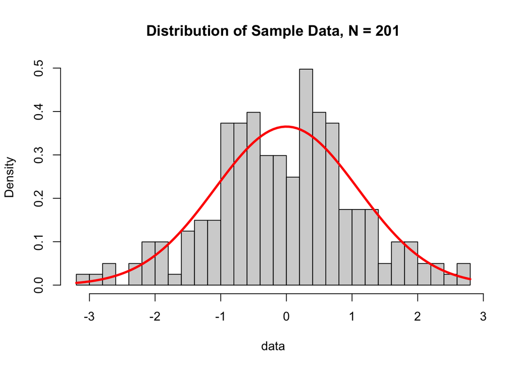

```r
hist(
  data,
  freq = FALSE,
  main = "Distribution of Sample Data, N = 201",
  breaks = 25
)
curve(
  dnorm(
    x,
    mu_hat,
    sigma_hat),
  lw = 3,
  col = "red",
  add = TRUE
  )
```

# Approximate the Sampling Distribution of the Median

```r
meds <- NA
for (i in 1:N){
  samples <- rnorm(
    N,
    mean = mu_hat,
    sd = sigma_hat)
  meds[i] <- median(samples)
}
mean(meds)
```

```
## [1] 0.003872125
```

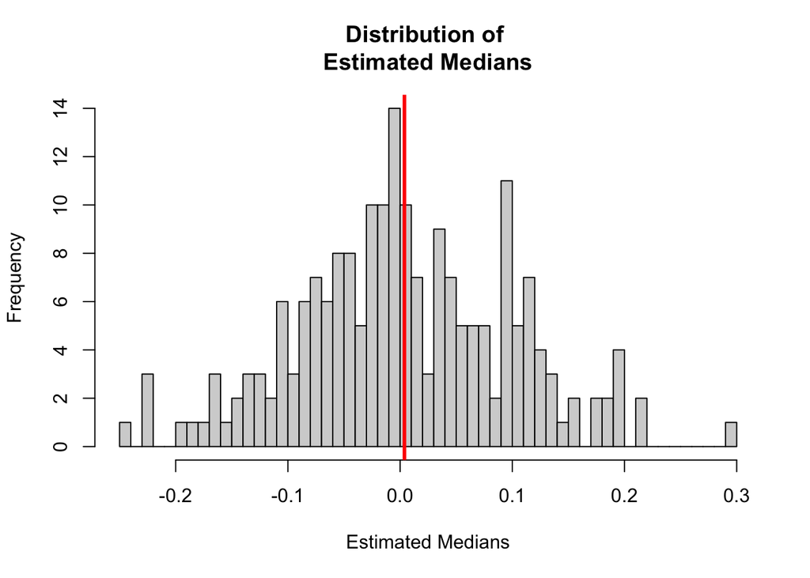

```r
hist(meds, breaks = 50, main = "Distribution of \nEstimated Medians", xlab = "Estimated Medians")
abline(v = mean(meds), lwd = 3, col = "red")
```

To approximate the sampling distribution of the median, we must first run a simulation of a standard normal distribution using the estimated parameters we found before. Using the same sample size, N = 201, we can then find the average median of the simulations and build a histogram to show the distribution of our sample medians. The average median found was 0.0038721, very close to our estimated mean above and the true median of a standard normal distribution (median = 0).

# 95% confidence interval

```r
boot_ci <- function(data, summary = "median"){
  # Hard coded number of draws
  R <- 5000
  # Set median as default summary measure
  sm <- get(summary)
  sampdist <- rep(NA, R)
  for(i in 1:R){
    b <- sample(data, length(data), replace = TRUE)
    sampdist[i] <- sm(b)
  }
  # Hard coded symmetric density interval
  quantile(sampdist, c(0.025, 0.975))
}
conf <- boot_ci(data)
conf
```

```
##       2.5%      97.5%
## -0.2263626  0.2142994
```

To calculate a 95% confidence interval from the approximated sampling distribution, we must use the `boot_ci()` function created above. This function uses simulation to create a dataset *sampdist* within the function. It then uses the `quantile()` function to chop off 2.5% from each end of the distribution, giving us the 95% confidence interval for our generated data. Using this function, we found the 95% confidence interval for the approximated sampling distribution to be -0.2263626, 0.2142994.

# Concept of Coverage Probability

```r
capture_median <- function(ci){
  # Hard coded 0 as parameter of interest
  1*(ci[1] < 0 & 0 < ci[2])
}
M <- 10 # Make small, we are still testing the code
captures <- rep(NA, M)
for(i in 1:M){
  captures[i] <-
    201 %>% generate_data %>% boot_ci %>% capture_median
}
capture_prob <- mean(captures)
capture_prob
```

```
## [1] 0.9
```

# Possible Changes

There are many different ways to change the simulation to learn more about the operating characteristics of your chosen method for constructing the 95% confidence interval. Examples are to test for a different parameter or use a different distribution when generating the dataset. You could also use a higher N for your generated dataset which would ultimately bring the coverage probability closer to 95%.